# Albatross bycatch modeling for Alaskan Federal fisheries

Jason E. Jannot, Eric J. Ward, Tom Good, Joe Krieger, Jason Gasper

2021-May-06

The canonical form of this code can be found at:

https://github.com/jjannot-NOAA/alaskastalbycatch

# Set-up

$$\newcommand{\mx}[1]{\mathbf{#1}}$$

## Load packages

```r
# set to final year in data set
  data.year <- "2020"

# libraries
  library(ggplot2)
  library(dplyr)
  library(knitr)
  library(tools)
  library(stringr)
  #library(kableExtra)
  library(devtools) # for using e.g., install_github(...)
  library(tidyr)
  library(janitor)
  library(lubridate)
  library(tibble)
  library(purrr)
  library(readr)
  library(captioner)
#installs EW's bycatch package from github if not already installed
  if(!require(bycatch)){
  devtools::install_github("ericward-noaa/bycatch")
    }else{
  library(bycatch)
    }

qdf <- function(.){data.frame(., stringsAsFactors = FALSE)}

table_nums <- captioner(prefix = "Table")
```

## Set drive & data year, load data

Change the `data.year` object to the most recent year in the data set. Change the `infiledrive` object to the path where the data are located.

```r
# USER CHANGES REQUIRED
#------------------------
# 1. Ensure data.year is set to final year in data set
# 2. Change the path to the data so it points to where data is housed

# set to final year in data set
  data.year <- "2020"

# path to data - REPLACE with your own path
  infiledrive <- paste0("V:/Input/MMSBT/",
                        data.year, "/Seabirds/Data/alaskadata/")

# catcher-vessel data
akcv <- readr::read_csv( file = paste0(infiledrive,
                                       "CATCHER_VESSELS_ALBATROSS.csv"))%>%
        clean_names()%>%
        qdf()

# catcher-processor data
akcp <- read_csv( file = paste0(infiledrive,
                                "CATCHERPROCESSOR_VESSELS_ALBATROSS.csv"))%>%
        clean_names()%>%
        qdf()
```

## Munge Data

```r
akcv <- akcv%>%
        dplyr::select(one_of(names(.)[names(.)%in%names(akcp)]))%>%
        mutate(vess_type = "CV")%>%
        qdf()

akcp <- akcp%>%
        mutate(vess_type = "CP")%>%
        dplyr::select(one_of(names(.)[names(.)%in%names(akcv)]))%>%
        qdf()

# ak <- rbind(akcv,akcp)
dim(akcv)
```

```
## [1] 32  9
```

```r
dim(akcp)
```

```
## [1] 48  9
```

```r
# dim(ak)
```

# Models

## Bayesian Modeling Approach

We use Bayesian models to estimate mean and variance of total bycatch. These methods have been used with other rare bycatch species, including cetaceans, delphinids, pinnipeds, sea turtles, and sharks (as cited in Martin et al. 2015). To do this, we model bycatch rate and inferr annual expected mortality from that rate given a specified level of effort.
In the simplest case, we can use a simple Poisson process model, where the total number of bycatch events are assumed to follow a Poisson distribution (see model M1 in Martin et al. 2015):
$$n_{takes,y}\sim Poisson(\lambda_y = \theta * E_y)$$
where:

$\mx{E_{y}} = \text{effort in year } y\\ \mx{\theta} = \text{estimated bycatch rate}\\ \mx{\lambda_{y}} = \text{mean expected bycatch in year } y\\ \mx{n_{takes,y}} = \text{observed number of bycatch (i.e., take) events in year }y\\$

All of these models assume that bycatch is:  
a. from a binomial distribution where p (but not N) is known.  
b. predicted by metrics of fishing effort.  
c. either constant or time-varying bycatch rates, depending on the model.

## Bycatch Example

Species: Black-footed Albatross (BFAL)  
Fishery: AK Catcher vessels (CV)  
Area: Gulf of Alaska (GOA)

## Poisson distribution with constant bycatch, no covariates

Start with the model from [Martin et al. (2015)](http://onlinelibrary.wiley.com/doi/10.1890/14-0059.1/abstract). This model wasn’t used in the paper, but models bycatch rate as constant using a Poisson distribution and does not use covariates. As a starting point for the example, we model the Alaska catcher vessels black-footed albatross (BFAL) bycatch in the GOA, becaues this fishery has a low coverage rate with (relatively) high bycatch. Thus makes for a good example case.  
The `fit_bycatch()` function fits the model to the observed data using the observed effort.

If divergent transition warnings or other issues indicating lack of convergence are a problem, we can try changing some of the control arguments, e.g.

```r
#Not Run
fit = fit_bycatch(count_birds ~ 1, data = d, time="year", effort="obs_hooks", family="poisson",  time_varying = FALSE, control=list(adapt_delta=0.99,max_treedepth=20))
```

We can also increase the iterations and number of chains from the defaults (1000 and 3),

```r
#Not Run
fit = fit_bycatch(count_birds ~ 1, data = d, time="year", effort="obs_hooks", family="poisson",
  time_varying = FALSE, iter=3000, chains=4)
```

### Plot - Poisson, constant bycatch rate, no covariates

`plot_fitted()` function plots the fitted values in a time series.

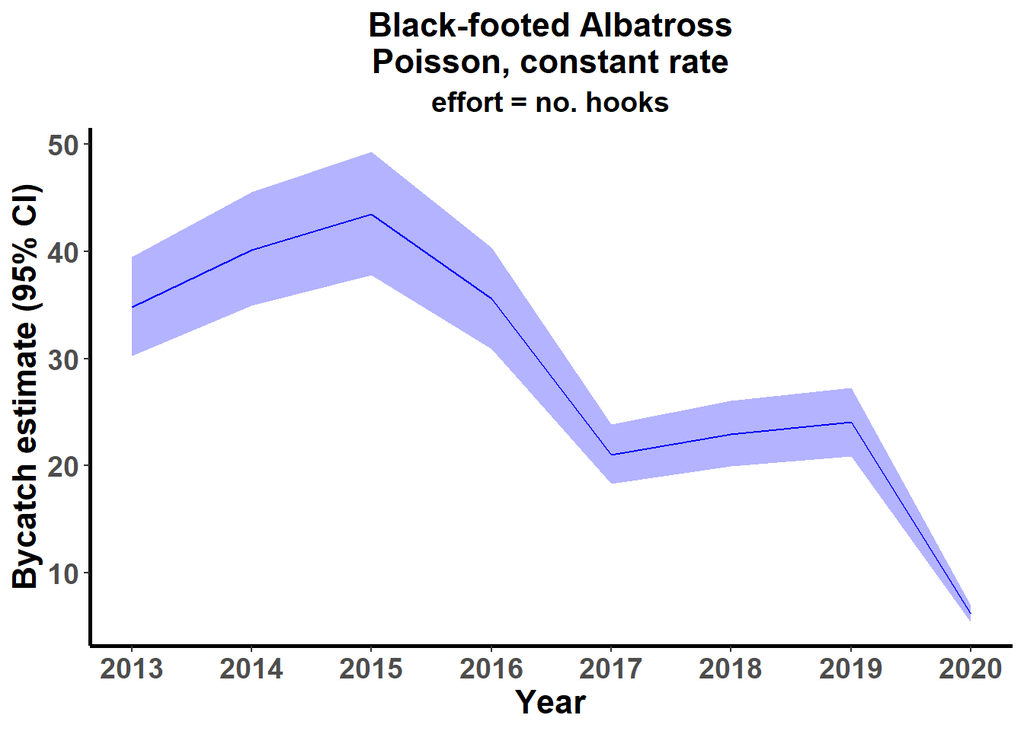

Figure 1. Estimated bycatch for observed vessels (not expanded by observer coverage), but including observed takes and effort.

```r
plot_fitted(fit, xlab="Year", ylab = "Bycatch estimate (95% CI)") +
      scale_x_continuous(breaks = seq(min(d$year), data.year, 1))  +
      labs( title = "Black-footed Albatross\nPoisson, constant rate",
            subtitle = "effort = no. hooks") +
      theme( panel.background = element_blank(),
             panel.border     = element_blank(),
             plot.background  = element_blank(),
             plot.title       = element_text(hjust = 0.5, face = "bold", size = rel(1.5)),
             plot.subtitle    = element_text(hjust = 0.5, face = "bold", size = rel(1.25)),
             panel.grid       = element_blank(),
             axis.text        = element_text(size = 14, face = "bold"),
             axis.title       = element_text(size = 16, face = "bold"),
             axis.line        = element_line(colour = "black", size = 1),
             legend.position  = "none")
```

We can include points using `include_points = TRUE` argument,

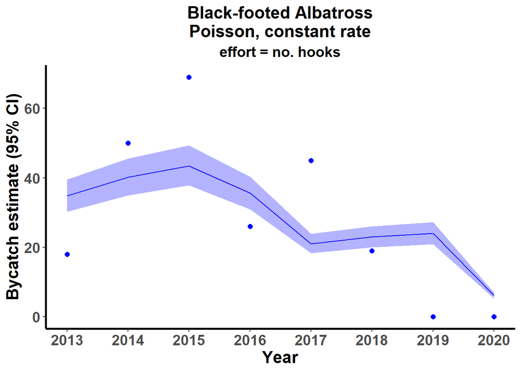

Figure 2. Same as Figure 1, but with points.

```r
plot_fitted(fit, xlab="Year", ylab = "Bycatch estimate (95% CI)", include_points = TRUE) +
      scale_x_continuous(breaks = seq(min(d$year), data.year, 1))  +
      labs( title = "Black-footed Albatross\nPoisson, constant rate",
            subtitle = "effort = no. hooks") +
      theme( panel.background = element_blank(),
             panel.border     = element_blank(),
             plot.background  = element_blank(),
             plot.title       = element_text(hjust = 0.5, face = "bold", size = rel(1.5)),
             plot.subtitle    = element_text(hjust = 0.5, face = "bold", size = rel(1.25)),
             panel.grid       = element_blank(),
             axis.text        = element_text(size = 14, face = "bold"),
             axis.title       = element_text(size = 16, face = "bold"),
             axis.line        = element_line(colour = "black", size = 1),
             legend.position  = "none")
```

### Extracting model selection information (LOOIC) - Poisson, constant rate

The `loo` package in R provides a nice interface for extracting leave one out information criterion (LOOIC) from `stanfit` objects. Like AIC, lower is better. Values of LOOIC can be used to compare models with the same response but different structure (covariates or not, time-varying bycatch or not, etc). Additional information on LOOIC can be found at [mc-stan.org](http://mc-stan.org/rstanarm/reference/loo.stanreg.html), [Vehtari et al. 2017](https://link.springer.com/article/10.1007/s11222-016-9696-4), or the vignette for the [loo package](https://cran.r-project.org/web/packages/loo/vignettes/loo2-example.html).

```r
bfal_loo1 <- loo::loo(fit$fitted_model)$estimates
```

```
## Warning: Some Pareto k diagnostic values are too high. See help('pareto-k-diagnostic') for details.
```

```r
bfal_loo1
```

```
##           Estimate        SE
## elpd_loo -77.47838 21.218071
## p_loo     10.84493  3.609409
## looic    154.95675 42.436141
```

The LOO importance sampling threw a warning suggesting some Pareto-K values were too high ( ~k > 0.7, see Vehtari et al. 2017 a & b). We can check the k values,

```r
loo::pareto_k_table(loo::loo(fit$fitted_model))
```

```
## Warning: Some Pareto k diagnostic values are too high. See help('pareto-k-diagnostic') for details.
```

```
## Pareto k diagnostic values:
##                          Count Pct.    Min. n_eff
## (-Inf, 0.5]   (good)     5     62.5%   133
##  (0.5, 0.7]   (ok)       1     12.5%   67
##    (0.7, 1]   (bad)      2     25.0%   7
##    (1, Inf)   (very bad) 0      0.0%   <NA>
```

## Expanding bycatch estimates to the fleet level - Poisson, constant rate

Continuing with our example, the observer coverage for the AK catcher-vessel dataset is less than 100%. Therefore, our estimates need to be expanded to the fleet to account for bycatch by the unobserved vessels. There are some important `control` arguments here that are left at defaults, but might need adjustment.

The `expand()` function of the `bycatch` package does the bycatch extrapolations to the entire fleet. This function runs a series of simulations, which can take a few minutes (at least at the NWFSC on our dedicated analytical server. YMMV.) Note there is an expand function in `tidyr` as well - be sure to use the correct function (e.g., `bycatch::expand`).

```r
expanded = bycatch::expand(fit, coverage = d$percent_obs_landing)
```

```
## Warning in bycatch::expand(fit, coverage = d$percent_obs_landing): Warning: maxX in the control list needs to be increased
##  to at least 42290 . Or try smaller values of the
##  sigfig_multiplier parameter. Please try running the expand() function again.
```

```r
expanded = bycatch::expand(fit, coverage = d$percent_obs_landing,
                  control = list(sigfig_multiplier = 100, mcmc_samples = 1000, maxX = 49100))
```

And we can then plot these estimates using the `bycatch::plot_expand()` function. Like the previous function we can specify whether to include the raw points or not.

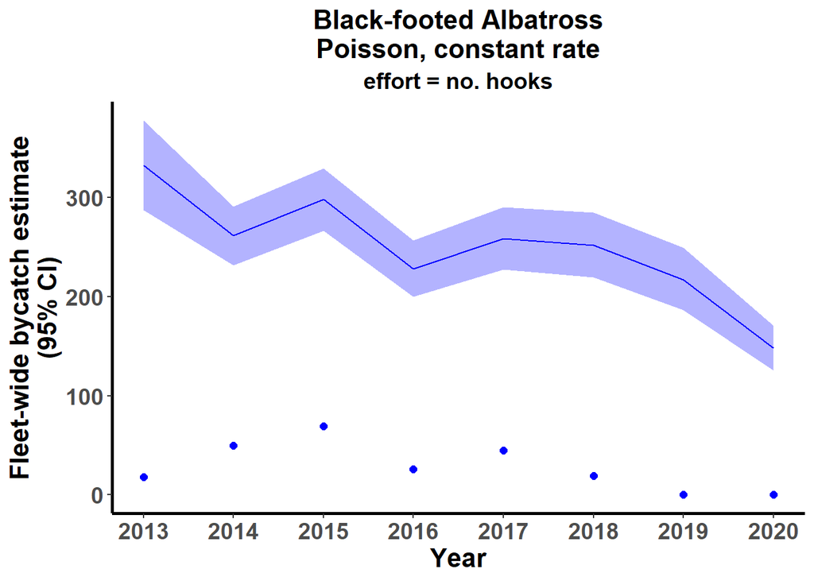

Figure 3. Estimated fleet-wide bycatch (observed & unobserved vessels) of black-footed albatross caught by catcher vessels in the Gulf of Alaska. The Poisson distribution incorporates data on takes, effort as the number of observed hooks, and observer coverage as a percentage of observed landings. Bycatch rate is assumed to be constant. Dots represent observed bycatch events.

```r
plot_expanded(fitted_model = fit,
              expanded_estimates = expanded,
              xlab="Year", ylab = "Fleet-wide bycatch estimate\n(95% CI)", include_points = TRUE) +
      scale_x_continuous(breaks = seq(min(d$year), data.year, 1))  +
      labs( title = "Black-footed Albatross\nPoisson, constant rate",
            subtitle = "effort = no. hooks") +
      theme( panel.background = element_blank(),
             panel.border     = element_blank(),
             plot.background  = element_blank(),
             plot.title       = element_text(hjust = 0.5, face = "bold", size = rel(1.5)),
             plot.subtitle    = element_text(hjust = 0.5, face = "bold", size = rel(1.25)),
             panel.grid       = element_blank(),
             axis.text        = element_text(size = 14, face = "bold"),
             axis.title       = element_text(size = 16, face = "bold"),
             axis.line        = element_line(colour = "black", size = 1),
             legend.position  = "none")
```

### Table of expanded bycatch estimates - Poisson, constant rate

We can also summarize the expanded estimates in table form:

| time | mean | median | lower95 | upper95 | model | bycatch.rate |
| --- | --- | --- | --- | --- | --- | --- |
| 2013 | 332 | 332 | 287 | 377 | Poisson | constant |
| 2014 | 261 | 261 | 232 | 291 | Poisson | constant |
| 2015 | 298 | 298 | 266 | 329 | Poisson | constant |
| 2016 | 228 | 228 | 199 | 256 | Poisson | constant |
| 2017 | 258 | 259 | 227 | 290 | Poisson | constant |
| 2018 | 252 | 252 | 219 | 284 | Poisson | constant |
| 2019 | 217 | 217 | 187 | 249 | Poisson | constant |
| 2020 | 148 | 148 | 125 | 170 | Poisson | constant |

[1] “Table 1: Fleet-wide bycatch estimates of black-footed albatross in the catcher vessel fleet fishing in the Gulf of Alaska for 2013-2020. Estimates are from a Poisson distribution, assuming a constant bycatch rate, with effort measured as the observed number of hooks, and the expansion based on the proportion of observed landings.”

## Negative binomial distribution, constant bycatch rate, no covariates

We can switch from the Poisson distribution to Negative Binomial distribution using the `family` argument. In theory, a negative binomial distribution might provide more realistic error estimates.

```r
fit_nb = fit_bycatch(count_birds ~ 1, data = d, time="year", effort="obs_hooks", family="nbinom2",
  time_varying = FALSE)
```

The degree of overdispersion here is stored in the variable `nb2_phi`, which we can get with

```r
phi_poisson = rstan::extract(fit_nb$fitted_model)$nb2_phi
mean(phi_poisson)
```

```
## [1] 0.896819
```

```r
expanded_nb = bycatch::expand(fit_nb, coverage = d$percent_obs_landing,
                     control = list(sigfig_multiplier = 100, mcmc_samples = 1000, maxX = 490000))
```

```
## Warning in bycatch::expand(fit_nb, coverage = d$percent_obs_landing, control = list(sigfig_multiplier = 100, : Warning: maxX in the control list needs to be increased
##  to at least 50435370 . Or try smaller values of the
##  sigfig_multiplier parameter. Please try running the expand() function again.
```

| time | mean | median | lower95 | upper95 | model | bycatch.rate |
| --- | --- | --- | --- | --- | --- | --- |
| 2013 | 422 | 210 | 18 | 1879 | negbinom | constant |
| 2014 | 345 | 176 | 50 | 1271 | negbinom | constant |
| 2015 | 355 | 210 | 69 | 1351 | negbinom | constant |
| 2016 | 260 | 152 | 26 | 1068 | negbinom | constant |
| 2017 | 348 | 176 | 45 | 1558 | negbinom | constant |
| 2018 | 288 | 156 | 19 | 1470 | negbinom | constant |
| 2019 | 335 | 138 | 0 | 1566 | negbinom | constant |
| 2020 | 200 | 90 | 0 | 1038 | negbinom | constant |

[1] “Table 2: Fleet-wide bycatch estimates (observed & unobserved vessels) of black-footed albatross in the catcher vessel fleet fishing in the Gulf of Alaska for 2013-2020. Estimates are from a negative binomial distribution, assuming a constant bycatch rate, with effort measured as the observed number of hooks, and the expansion based on the proportion of observed landings.”

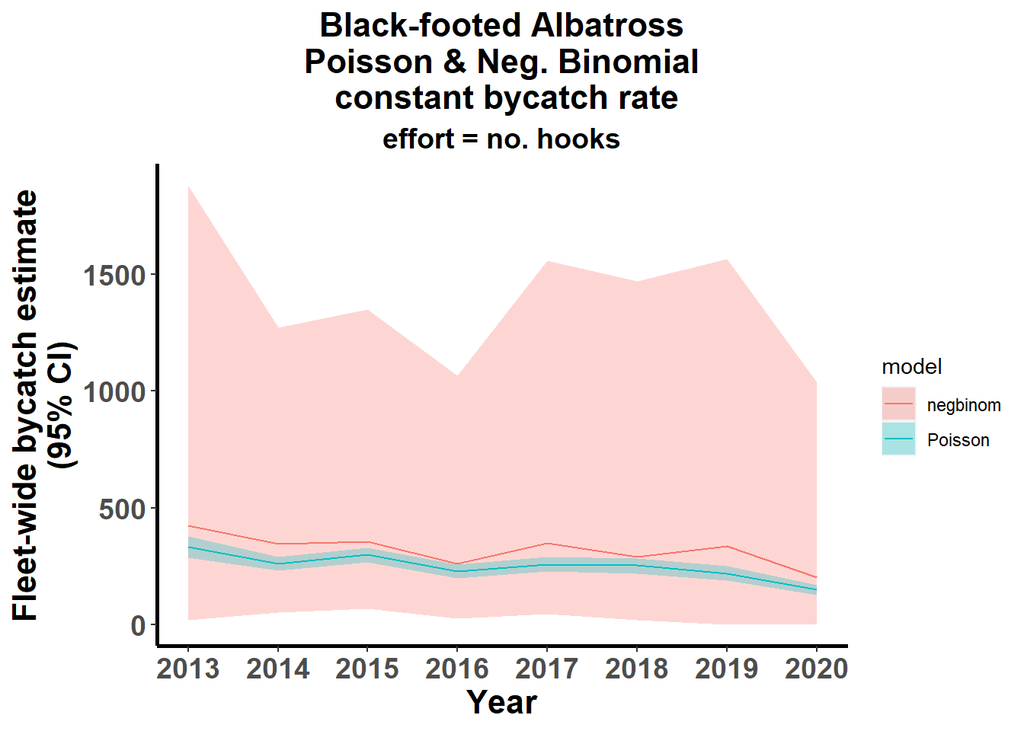

## Fit model with time-varying effects - Poisson, time-varying bycatch

To incorporate potential autocorrelation, we can fit a model with time-varying random effects. This is equivalent to a dynamic linear model with time varying intercept in a Poisson GLM.

Here we use the BFAL data from the GOA with a Poisson distribution to model time-varying bycatch rates. Note we needed to increase the `maxX` to 75834 for this example.

```r
fit_Ptv = fit_bycatch(count_birds ~ 1, data = d, time="year", effort="obs_hooks", family="poisson", time_varying = TRUE)
```

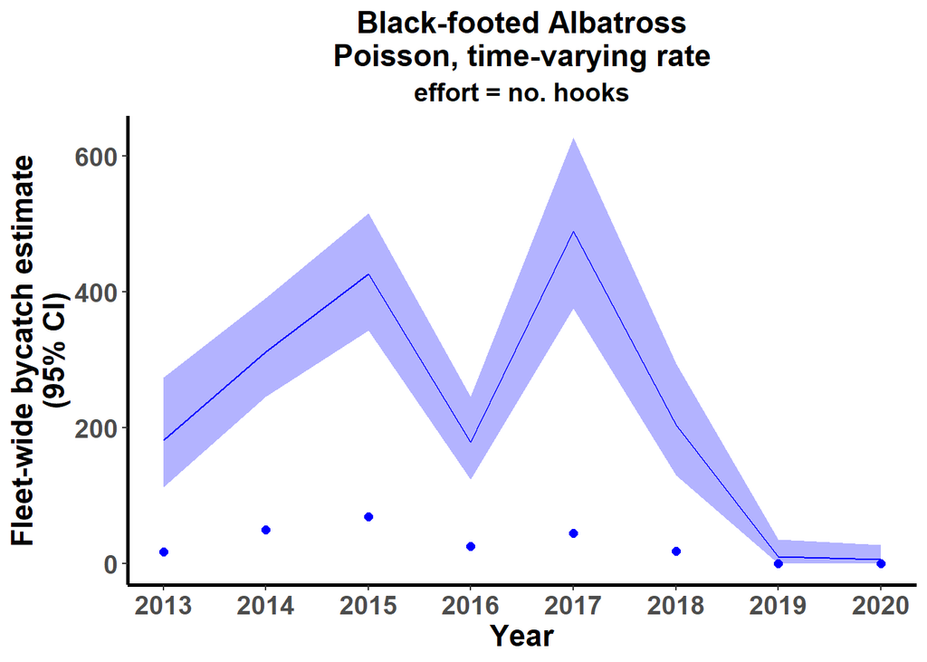

Figure 5. Estimated fleet-wide bycatch (observed & unobserved vessels) of black-footed albatross caught by catcher vessels in the Gulf of Alaska. The model assumes a Poisson distribution when incorporating data on takes, effort as the number of observed hooks, and observer coverage as a percentage of observed landings. Bycatch rate varies among years.

```r
expanded_tv = bycatch::expand(fit_Ptv, coverage = d$percent_obs_landing,
                     control = list(sigfig_multiplier = 100, mcmc_samples = 1000, maxX = 75834))

plot_expanded(fitted_model = fit_Ptv,
              expanded_estimates = expanded_tv,
              xlab="Year", ylab = "Fleet-wide bycatch estimate\n(95% CI)", include_points = TRUE) +
      scale_x_continuous(breaks = seq(min(d$year), data.year, 1))  +
      labs( title = "Black-footed Albatross\nPoisson, time-varying rate",
            subtitle = "effort = no. hooks") +
      theme( panel.background = element_blank(),
             panel.border     = element_blank(),
             plot.background  = element_blank(),
             plot.title       = element_text(hjust = 0.5, face = "bold", size = rel(1.5)),
             plot.subtitle    = element_text(hjust = 0.5, face = "bold", size = rel(1.25)),
             panel.grid       = element_blank(),
             axis.text        = element_text(size = 14, face = "bold"),
             axis.title       = element_text(size = 16, face = "bold"),
             axis.line        = element_line(colour = "black", size = 1),
             legend.position  = "none")
```

## Example with covariates

Following [Martin et al. 2015](http://onlinelibrary.wiley.com/doi/10.1890/14-0059.1/abstract) we can include fixed or continuous covariates.

For example, we could include a julian day or a break point representing a regulatory change in the data. We could model the first variable as a continuous predictor and the second as a factor.

For the BFAL CV case, we will look at the difference between GOA and BAI.

```r
d <- akcv%>%
      filter(name == "Black-footed Albatross")%>%
      qdf()
```

Using the formula interface makes it easy to include covariates, but in this case, we need to increase the iterations to make sure we have enough effective sample sizes (to see original warnings, remove the ‘iter’ argument from the function below and re-run).

```r
fit_Pcov = fit_bycatch(count_birds ~ fmp,  # which is same as ~ 1 + fmp and fmp + offset(year)
                       data = d, time = "year", effort = "obs_hooks",
                       family="poisson", time_varying = FALSE,
                       iter = 3000)
```

We can get the covariate effects out with the following call:

```r
betas = rstan::extract(fit_Pcov$fitted_model)$beta
betas <- betas%>%
         qdf()%>%
         dplyr::rename(intercept = X1, fmp = X2)%>%
         qdf()
betas <- pivot_longer(betas, cols = 1:2, names_to = "parameter", values_to = "estimate" )%>%
         qdf()
```

Note that ‘betas’ has 2 columns. These correspond to (1) the intercept and (2) the `fmp` predictor. If we didn’t include the covariates, we’d still estimate beta[1] as the intercept. Also note - these are *distributions* of the parameters.

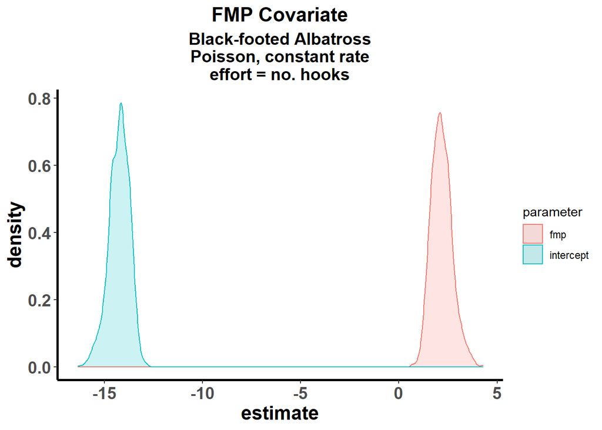

# References

Good, T. P., E. Ward, J. Jannot, R. Shama, and J. McVeigh. 2019. [Observed and Estimated Bycatch of Short-tailed Albatross in U.S. West Coast Groundfish Fisheries 2002-2017. National Marine Fisheries Service, NWFSC, 2725 Montlake Blvd E., Seattle, WA 98112.](https://www.pcouncil.org/documents/2019/06/agenda-item-i-4-a-nmfs-report-6-observed-and-estimated-bycatch-of-short-tailed-albatross-in-u-s-west-coast-groundfish-fisheries-2016-2017-electronic-only.pdf/)

Martin, S.L., S.M. Stohs, and J.E. Moore. 2015. [Bayesian inference and assessment for rare‐event bycatch in marine fisheries: a drift gillnet fishery case study. Ecological Applications, 25(2):416-429.](http://onlinelibrary.wiley.com/doi/10.1890/14-0059.1/abstract)

Vehtari, A., Gelman, A., and Gabry, J. (2017a). Practical Bayesian model evaluation using leave-one-out cross-validation and WAIC. Statistics and Computing 27(5), 1413-1432. (journal version, preprint arXiv:1507.04544).

Vehtari, A., Gelman, A., and Gabry, J. (2017b). [Pareto smoothed importance sampling.](https://arxiv.org/abs/1507.02646) preprint

Ward, E.J. 2017. [bycatch: Using Bayesian generalized linear models for estimating bycatch rates and generating fleet-level expansions.](https://github.com/ericward-noaa/bycatch)

Ver Hoef, Jay M. and Boveng, Peter L., (2007). [Quasi-Poisson vs. negative binomial regression: How should we model overdispersed count data? Ecology, 88(11):2766-2772](http://fisher.utstat.toronto.edu/reid/sta2201s/QUASI-POISSON.pdf)